# La estructura de las proteínas

Ciro Ramírez Suástegui, José Damián Martínez Reyes

05/03/2016

### 1. Creen un repositorio git en tepeu, por ejemplo en su home/algoritmos_3D, para ir añadiendo ahí las tareas de los 4 días y sus respectivos informes.

Enlace: https://github.com/cramirezs/homework

### 2. Que completen los puzzles de Foldit al menos hasta el nivel 4-5, y por el camino vayan tomando capturas de pantalla que reflejen algunos de los conceptos teóricos que hablamos por la mañana:

#### 2.1 Ejemplo de aminoácido con cadena lateral aromática.

[figure not shown]

#### 2.2 Ejemplo de aminoácido con cadena lateral chica.

[figure not shown]

#### 2.3 Ejemplo de giro en torno a los ángulos phi/psi de un residuo seleccionado, ¿que pasa cuando si sus vecinos tienen cadenas laterales voluminosas?

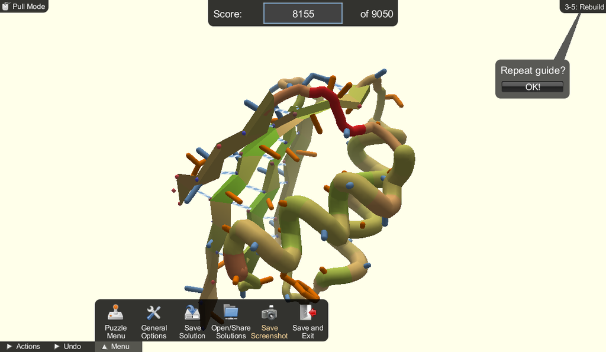

[figure not shown]

Cuando los vecinos tienen cadenas laterales voluminosas se restringe mucho la movilidad de los ángulos phi/psi. Las imágenes muestran giros en los ángulos (zonas rojas) y se puede ver cómo este cambio genera interacciones no permitidas con una alfa hélice adyacente.

#### 2.4 Ejemplo de puentes de hidrógeno entre resíduos de una alfa-hélice y entre hojas de una lámina beta.

[figure not shown]

Desde el punto de vista algorítmico, ¿cuál de los estados de estructura secundaria les parece más difícil de programar? Las láminas β nos parecen más difíciles de programar debido a que tienes que considerar las interacciones mediante puentes de hidrógeno entre cada lámina, si es el caso en que interactúan varias, mientras que las hélices α tienen menos de estos enlaces y no suelen haber entre varias de estas estructuras.

#### 2.5 Ejemplo de residuo hidrofóbico expuesto y luego correctamente “enterrado” tras operaciones con los vecinos.

**Expuesto:**

[figure not shown]

**“Enterrado”:**

[figure not shown]

#### 2.6 Ejemplo de conformaciones distintas con puntuaciones similares, para hacer patente el problema de evaluar lo correcto de una conformación.

Obsérvese que es la misma proteína “4-4 y que la diferencia en score es de apenas tres unidades. **Primero una forma “cerrada”:**

[figure not shown]

**Ahora una forma abierta:**

[figure not shown]

#### 2.7 De acuerdo con http://goo.gl/G8ChC2 calcula el tiempo que llevaría explorar todas las conformaciones posibles de uno de los péptidos o proteínas que utilicen en los puzzles.

[figure not shown]

**Tamaño del péptido:** 16 aminoácidos  
Tiempo de cambio = 10^-13s  
**Estados diferentes:** 10 (por ejemplo)

Tiempo estimado = 10<sup>16</sup>*10<sup>-13</sup> = 103s para analizar todas las posibles estructuras de esta proteína. Es un péptido muy pequeño y sólo son 1000 segundos pero no se compara en nada con los 5 seg que tarda E. coli en plegar una proteína (en este caso incluso sea menor).